# Analysis of longitudinal data

Next, I plot graphs showing average (mean) profiles for each group along with indication of the variation of the observations at each time point, in this case the standard error of mean.

se = std(x) / sqrt(N)

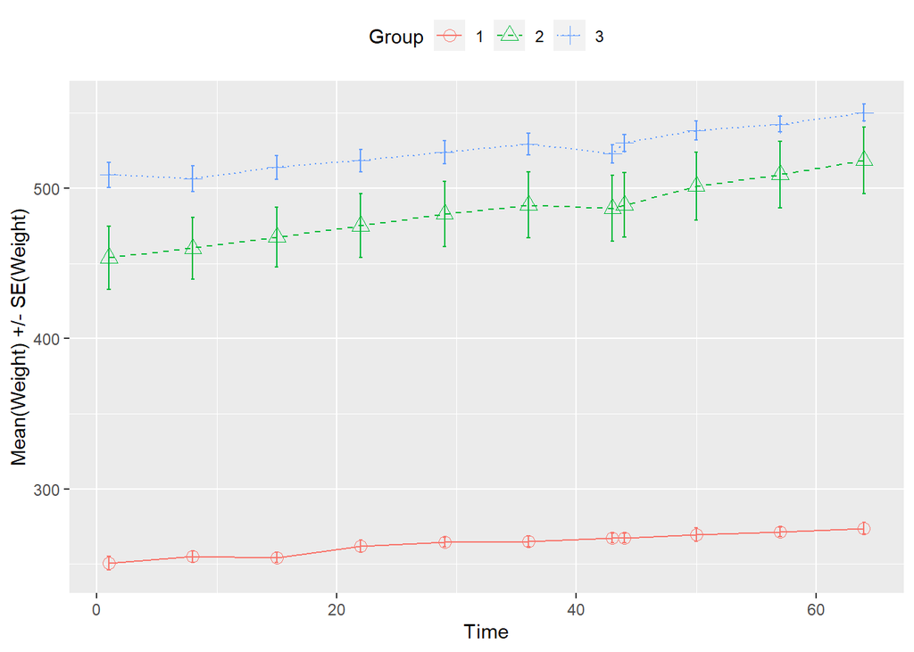

```r
#Number of days, baseline (day 1) included
n <- RATSL$Time %>% unique() %>% length()

#Summary data with mean and standard error of Weight by treatment and week
RATSS <- RATSL %>%
  group_by(Group, Time) %>%
  summarise(mean = mean(Weight), se = (sd(Weight)/sqrt(n)) ) %>%
  ungroup()

#Plotting the mean profiles
ggplot(RATSS, aes(x = Time, y = mean, linetype = Group, shape = Group, color = Group)) +
  geom_line() +
  scale_linetype_manual(values = c(1,2,3)) +
  geom_point(size=3) +
  scale_shape_manual(values = c(1,2,3)) +
  geom_errorbar(aes(ymin=mean-se, ymax=mean+se, linetype="1"), width=0.3) +
  theme(legend.position = c(0.8,0.8,0.8)) + theme(legend.position = "top") +
  scale_y_continuous(name = "Mean(Weight) +/- SE(Weight)")
```

The plot highlights the difference in weight between group1 and groups 2 and 3. Although, groups 2 and 3 are more similar to each other comprising heavier rats than in the first group, they are significantly different as well. Group 2 has highest variation, shown as standard errors of the means here. The differences between the groups seem to be outside the standard error in all time points for all three groups which suggests there might be statistically significant difference between the groups in respect to the mean weight values.

**Applying the Summary Measure Approach**

The summary measure for this analysis will be time mean. First I calculate this measure and then look at boxplots of the measure for each group.

```r
# Create a summary data by group and subject with mean as the summary variable (ignoring baseline week 0).
RATSLSS <- RATSL %>%
  filter(Time > 1) %>%
  group_by(Group, ID) %>%
  summarise(mean=mean(Weight) ) %>%
  ungroup()
RATSL
```

```
## # A tibble: 176 x 6
##    ID    Group WD    Weight  Time stdWeight
##    <fct> <fct> <chr>  <int> <int>     <dbl>
##  1 1     1     WD1      240     1    -1.00
##  2 2     1     WD1      225     1    -1.12
##  3 3     1     WD1      245     1    -0.961
##  4 4     1     WD1      260     1    -0.842
##  5 5     1     WD1      255     1    -0.882
##  6 6     1     WD1      260     1    -0.842
##  7 7     1     WD1      275     1    -0.723
##  8 8     1     WD1      245     1    -0.961
##  9 9     2     WD1      410     1     0.350
## 10 10    2     WD1      405     1     0.311
## # ... with 166 more rows
```

```r
# Glimpse the data
glimpse(RATSLSS)
```

```
## Rows: 16
## Columns: 3
## $ Group <fct> 1, 1, 1, 1, 1, 1, 1, 1, 2, 2, 2, 2, 3, 3, 3, 3
## $ ID    <fct> 1, 2, 3, 4, 5, 6, 7, 8, 9, 10, 11, 12, 13, 14, 15, 16
## $ mean  <dbl> 263.2, 238.9, 261.7, 267.2, 270.9, 276.2, 274.6, 267.5, 443.9, 4~
```

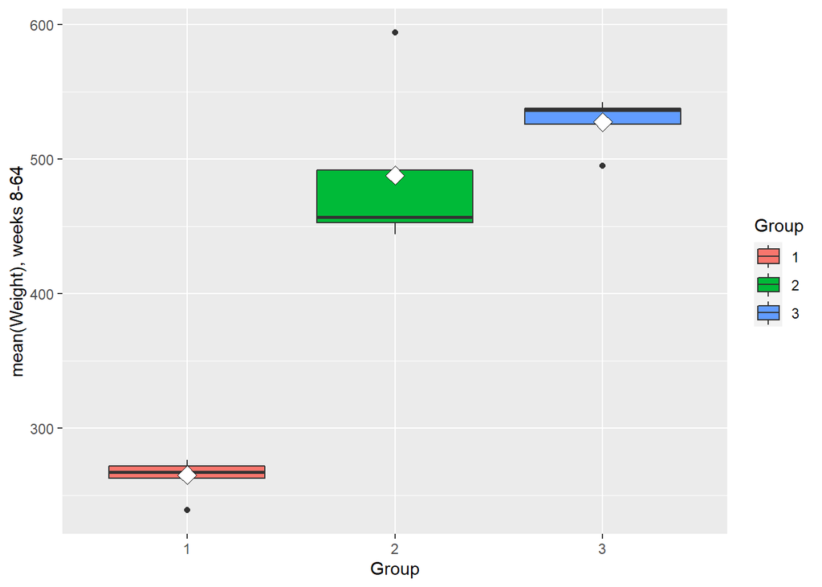

```r
# Draw a boxplot of the mean versus treatment
ggplot(RATSLSS, aes(x=Group, y=mean, fill=Group)) +
  geom_boxplot() +
  stat_summary(fun="mean", geom="point", shape=23, size=4, fill="white") +
  scale_y_continuous(name="mean(Weight), weeks 8-64")
```

```r
# Create a new data by filtering the outlier and adjust the ggplot code the draw the plot again with the new data
RATSLSS2 <- filter(RATSLSS, (Group==1 & mean > 250)|(Group==2 & mean < 550)| (Group==3 & mean > 500))
RATSLSS2
```

```
## # A tibble: 13 x 3
##    Group ID     mean
##    <fct> <fct> <dbl>
##  1 1     1      263.
##  2 1     3      262.
##  3 1     4      267.
##  4 1     5      271.
##  5 1     6      276.
##  6 1     7      275.
##  7 1     8      268.
##  8 2     9      444.
##  9 2     10     458.
## 10 2     11     456.
## 11 3     14     536.
## 12 3     15     542.
## 13 3     16     536.
```

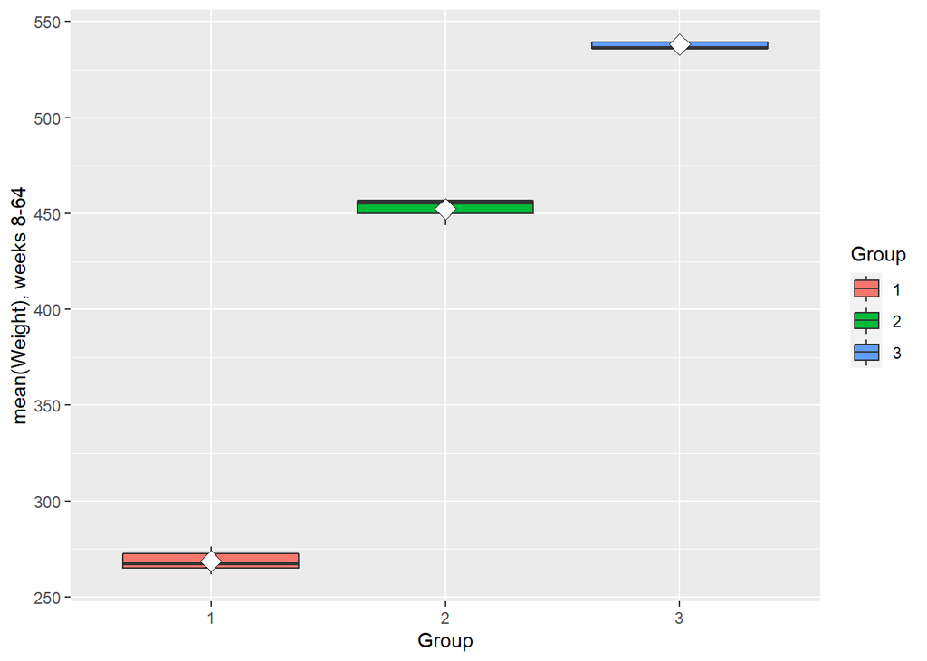

```r
# Draw a boxplot of the mean versus treatment
ggplot(RATSLSS2, aes(x=Group, y=mean, fill=Group)) +
  geom_boxplot() +
  stat_summary(fun="mean", geom="point", shape=23, size=4, fill="white") +
  scale_y_continuous(name="mean(Weight), weeks 8-64")
```

The mean summary measure is more variable in the second group and its distribution in this group is somewhat skew. The distribution of the group 3 is skew as well. Every group has an outlier, which might bias the conclusions from further comparisons of the groups, so I removed them from the data.

**T-test and ANOVA**

I will calculate t-test between groups 2 and 3, as they are closer to each other.

```r
# filter groups 2 and 3
RATSLSS23 <- filter(RATSLSS2,(Group==2| Group==3))
RATSLSS23$Group <- factor(RATSLSS23$Group)

#structure
str(RATSLSS23)
```

```
## tibble [6 x 3] (S3: tbl_df/tbl/data.frame)
##  $ Group: Factor w/ 2 levels "2","3": 1 1 1 2 2 2
##  $ ID   : Factor w/ 16 levels "1","2","3","4",..: 9 10 11 14 15 16
##  $ mean : num [1:6] 444 458 456 536 542 ...
```

```r
#t-test
t.test(mean ~ Group, data = RATSLSS23, var.equal = TRUE)
```

```
##
##  Two Sample t-test
##
## data:  mean by Group
## t = -18.235, df = 4, p-value = 5.32e-05
## alternative hypothesis: true difference in means between group 2 and group 3 is not equal to 0
## 95 percent confidence interval:
##  -98.94088 -72.79246
## sample estimates:
## mean in group 2 mean in group 3
##        452.4000        538.2667
```

Now I fit the linear model with the mean as the response. First, I will add the baseline (day 1) as a new variable to the summary data. This might be useful because baseline measurements in a longitudinal study like this are often correlated with the summary measure. Using the baseline weight here as a covariate might improve the precision of the model.

```r
#Load original data for creating baseline
RATS <- read.table("https://raw.githubusercontent.com/KimmoVehkalahti/MABS/master/Examples/data/rats.txt",
                   sep  = "\t", header = T)

#Adding the baseline
RATSLSS2 <- RATSLSS %>%
  mutate(baseline = RATS$WD1)

#Fitting the linear model with the mean as the response
fit <- lm(mean ~ baseline + Group, data = RATSLSS2)

#Checking the summary statistics for this model
summary(fit)
```

```
##
## Call:
## lm(formula = mean ~ baseline + Group, data = RATSLSS2)
##
## Residuals:
##     Min      1Q  Median      3Q     Max
## -23.905  -4.194   2.190   7.577  14.800
##
## Coefficients:
##             Estimate Std. Error t value Pr(>|t|)
## (Intercept) 33.16375   21.87657   1.516   0.1554
## baseline     0.92513    0.08572  10.793 1.56e-07 ***
## Group2      34.85753   18.82308   1.852   0.0888 .
## Group3      23.67526   23.25324   1.018   0.3287
## ---
## Signif. codes:  0 '***' 0.001 '**' 0.01 '*' 0.05 '.' 0.1 ' ' 1
##
## Residual standard error: 11.68 on 12 degrees of freedom
## Multiple R-squared:  0.9936, Adjusted R-squared:  0.992
## F-statistic: 622.1 on 3 and 12 DF,  p-value: 1.989e-13
```

```r
#Computing the analysis of variance (ANOVA) table for the fitted model
anova(fit)
```

```
## Analysis of Variance Table
##
## Response: mean
##           Df Sum Sq Mean Sq   F value   Pr(>F)
## baseline   1 253625  253625 1859.8201 1.57e-14 ***
## Group      2    879     439    3.2219  0.07586 .
## Residuals 12   1636     136
## ---
## Signif. codes:  0 '***' 0.001 '**' 0.01 '*' 0.05 '.' 0.1 ' ' 1
```

ANOVA test hypotheses:

Null hypothesis: the means of the different groups are the same Alternative hypothesis: At least one sample mean is not equal to the others.

The ANOVA result shows that baseline weight does have a very significant effect on the mean weight of rats in this study. Therefore, adding the baseline weight as a covariate definitely helped construct a better model to explain the data.

## PART 2: Analysis of the BPRSL dataset

**Analysis follows Chapter 9 from Vehkalahti, Kimmo & Everitt, Brian S. (2019). Multivariate Analysis for the Behavioral Sciences , Second Edition. Chapman and Hall/CRC, Boca Raton, Florida, USA.**

BPRSL dataset is a longitudinal data set, consisting of 40 study subjects who were randomly assigned to two treatment groups, and rated on the “brief psychiatric rating scale” (BPRS) before and during the treatment. The treatment lasted eight weeks. The BPRS is used to evaluate patients who are suspected to have schizophrenia. A high score indicates severe symptoms, such hostility, suspiciousness and hallucinations.

Load the BPRSL dataset in long form and check the structure, dimensions and summary of the dataset.

```r
BPRSL <- read.csv("./Data/BPRSL.csv")

str(BPRSL)
```

```
## 'data.frame':    360 obs. of  5 variables:
##  $ treatment: int  1 1 1 1 1 1 1 1 1 1 ...
##  $ subject  : int  1 2 3 4 5 6 7 8 9 10 ...
##  $ weeks    : chr  "week0" "week0" "week0" "week0" ...
##  $ bprs     : int  42 58 54 55 72 48 71 30 41 57 ...
##  $ week     : int  0 0 0 0 0 0 0 0 0 0 ...
```

```r
dim(BPRSL)
```

```
## [1] 360   5
```

```r
summary(BPRSL)
```

```
##    treatment      subject         weeks                bprs            week
##  Min.   :1.0   Min.   : 1.00   Length:360         Min.   :18.00   Min.   :0
##  1st Qu.:1.0   1st Qu.: 5.75   Class :character   1st Qu.:27.00   1st Qu.:2
##  Median :1.5   Median :10.50   Mode  :character   Median :35.00   Median :4
##  Mean   :1.5   Mean   :10.50                      Mean   :37.66   Mean   :4
##  3rd Qu.:2.0   3rd Qu.:15.25                      3rd Qu.:43.00   3rd Qu.:6
##  Max.   :2.0   Max.   :20.00                      Max.   :95.00   Max.   :8
```

```r
# Factor treatment & subject
BPRSL$treatment <- factor(BPRSL$treatment)
BPRSL$subject <- factor(BPRSL$subject)

glimpse (BPRSL)
```

```
## Rows: 360
## Columns: 5
## $ treatment <fct> 1, 1, 1, 1, 1, 1, 1, 1, 1, 1, 1, 1, 1, 1, 1, 1, 1, 1, 1, 1, ~
## $ subject   <fct> 1, 2, 3, 4, 5, 6, 7, 8, 9, 10, 11, 12, 13, 14, 15, 16, 17, 1~
## $ weeks     <chr> "week0", "week0", "week0", "week0", "week0", "week0", "week0~
## $ bprs      <int> 42, 58, 54, 55, 72, 48, 71, 30, 41, 57, 30, 55, 36, 38, 66, ~
## $ week      <int> 0, 0, 0, 0, 0, 0, 0, 0, 0, 0, 0, 0, 0, 0, 0, 0, 0, 0, 0, 0, ~
```

Plot of bprs against weeks for bprs data, ignoring the repeated-measures structure of the data but identifying the group to which each observation belongs.

[figure not shown]

```r
ggplot(BPRSL, aes(x = week, y = bprs, group = subject)) +
      geom_text(aes(label = treatment, color = treatment)) +
      scale_x_continuous(name = "BPRS", breaks = seq(0, 8, 1)) +
      scale_y_continuous(name = "Weight (grams)") +
      theme_light() +
      theme(panel.grid.major = element_blank(), panel.grid.minor = element_blank())
```

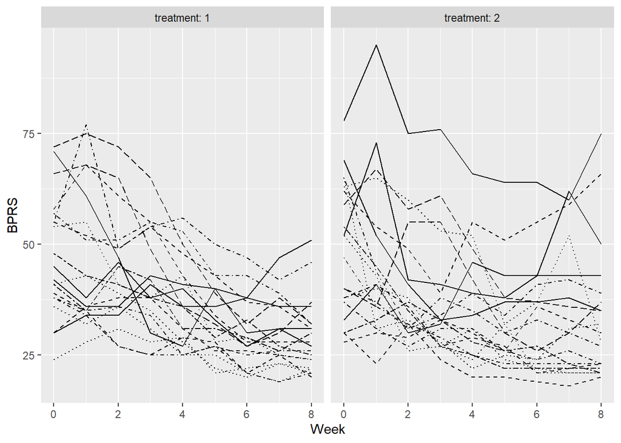

```r
#Plotting the BPRSL data
ggplot(BPRSL, aes(x = week, y = bprs, linetype = subject)) +
  geom_line() +
  scale_linetype_manual(values = rep(1:10, times=4)) +
  facet_grid(. ~ treatment, labeller = label_both) +
  theme(legend.position = "none") +
  scale_y_continuous(name = "BPRS", limits = c(min(BPRSL$bprs), max(BPRSL$bprs))) +
  scale_x_continuous(name = "Week", limits = c(min(BPRSL$week), max(BPRSL$week)))
```

```r
# this plot is for later comparison with the fitted values
plot1 <- ggplot(BPRSL, aes(x = week, y = bprs, group=interaction(subject, treatment))) +
        geom_line(aes(color=treatment, linetype=treatment)) +
        scale_x_continuous(name = "weeks", breaks = seq(0, 8, 4)) +
        scale_y_continuous(name = "bprs") +
        theme(legend.position = "top")
```

Each line in the plot is an individual study subject (one of the 40 men in the study). This seems to show that the BPRS value decreased for most individuals during the study. From this plot alone it is not clear to me if there is any difference between the treatment groups.